# Computational Statistics 4.1: Statistics and Tests

## Statistics and Tests

### Overview

This lesson shows how to calculate scores and percentiles with the normal distribution.

### Objectives

After completing this module, students should be able to:

1. Use z scores to calculate percentiles.
2. Calculate z scores from percentiles
3. Use and apply the z table.

### Readings

Schumacker, Ch 4-6

## Normal populations

The **normal distribution** (or **Gaussian distribution** or **Bell curve**) is the most important probability distribution to know about because it fits many different phenomena.

- Scores of a large number of students in an exam.
- Heights
- Blood pressure
- IQ score
- …

## Features of the normal distribution

**Features of the normal distribution:**

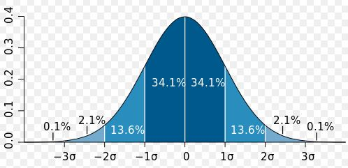

- It has two key parameters: the **mean** and the **standard deviation**.
- Derived from a probability function describing how the values of a variable are clustered.
- mean = median = mode
- Symmetric distribution: clustering around the mean. 50% of values fall on both sides of the mean.
- The standard deviation helps determine the proportion of the values within a specified number of standard deviations from the mean: 68% of the observations fall within 1 sd; 95% fall within 2 sd.

Wait, what is the mean and standard deviation again?

## Normal Distribution != Uniform distribution

**How is the uniform distribution different from the normal distribution?**

Show me some answers

**Uniform:**

- Really uniform: all values are equally probable.
- Hard to find in practice

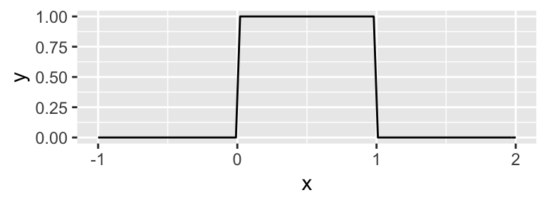

```r
library(ggplot2)
uniformfun <- function(x){ifelse(x>=0&x<=1,1,0)}
ggplot(data=data.frame(x=c(-1, 2)), aes(x)) + stat_function(fun=uniformfun)
```

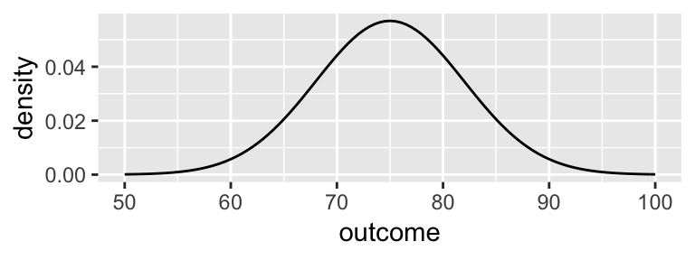

```r
normfun <- function(x){dnorm(x,75,7)}
ggplot(data=data.frame(x=c(50, 100)),aes(x)) + ylab("density") + xlab("outcome") +
  stat_function(fun=normfun)
```

## Plot normal distribution in R

Here is the pdf and cdf of a normal distribution with a mean of 75 and a standard deviation of 7:

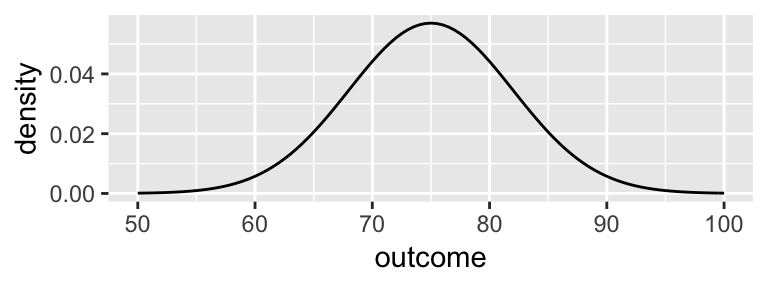

```r
normfun <- function(x){dnorm(x,75,7)}
ggplot(data=data.frame(x=c(50, 100)),aes(x)) + ylab("density") + xlab("outcome") +
  stat_function(fun=normfun)
```

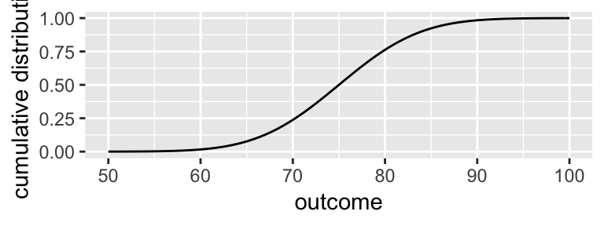

```r
cumlfun <- function(x){pnorm(x,75,7)}
ggplot(data=data.frame(x=c(50, 100)),aes(x)) + ylab("cumulative distribution") + xlab("outcome") +
  stat_function(fun=cumlfun)
```

## Standard normal distributions

Here, we need a **standard normal distribution (the Z-distribution):**

- Mean is 0, standard deviation is 1.
- Involves a process of standardization so that we can compare individual scores from different normally distributed populations with different means and standard deviations.

Working with this standardization involves **two steps**:

1. Calculate Z-Scores
2. From Z-Scores to Percentiles

### Step 1: Calculate Z scores

$$Z = \frac{X - \mu}{\sigma}$$
This z-score gives you an indication of how many standard deviations your height is above or below the mean.

### Step 2: Find the Percentile in the z table

Lots of other people did the math for you and created a beautiful “Z-table” where you can find the percentile associated with certain Z-scores.

Here’s an example of part of a z-table:

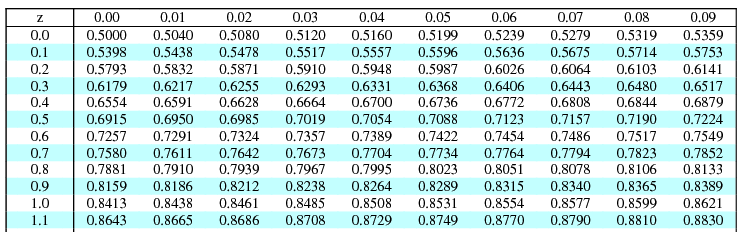

(See for a complete ztable and some really helpful info: http://www.statisticshowto.com/tables/z-table/)

To get the percentile, look up the first digit of the z-score on the left, and the second along the top (eg, row 11 column 1, z=1.00, corresponds to 0.8413); or for the reverse, find the percentile and match to the z-score.

### The Contemporary Solution: Z Scores and Percentiles in R

If the mean is 0 and the standard deviation is 1, we can calculate the percentile for being 1 sd above the mean with pnorm as usual:

```r
pnorm(1,0,1)
```

```
[1] 0.8413447
```

If we want the percentile in an exam where the mean score was 75, sd was 7, and you got an 82:

```r
pnorm(82,75,7)
```

```
[1] 0.8413447
```

### From percentiles to scores

Conversely, if you know you are in the 15th percentile (ie, cdf(x) = 0.15) and the mean is 75 and sd is 7, then what score did you get:

```r
qnorm(0.15,75,7)
```

```
[1] 67.74497
```

You can visually confirm these last two results by looking at the previous graphs. Note how a score of 82 is a bit above 0.75 on the cdf (0.8413 to be precise), and that the 0.15 percentile (y axis) corresponds to a score a bit under 70 (67.74 to be precise).

Whenever we want to move back and forth between percentiles and raw scores (or whatever our measurement is), we go via the z-score:

$$z = \frac{x-\mu}{\sigma}$$

Again, the z score is just how many $\sigma$s a value ($x$) is above or below the mean ($\mu$). A $x$ that is two sd’s above the mean means that $x - \mu$ is $2\sigma$, which yields a z-score of $2$.

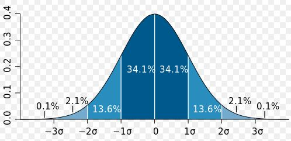